# DrivenData.org - Predicting Blood Donations

On Drivendata.org, a Kaggle-like site which runs modeling competitions using data from non-profits, there’s a warmup competition which asks you to predict whether a person will donate blood in a given time window based on some past donation metrics [Warm Up: Predict Blood Donations](https://www.drivendata.org/competitions/2/warm-up-predict-blood-donations). It seemed like a good way to brush up on techniques for modeling binary random variables. For the blood donations task the predictor variables are:  
- Months since last donation  
- Number of donations  
- Total volume donated (cc)  
- Months since first donation

and the response variable is binary:  
- made donation in March 2007.

Note some necissary formatting and setup code is not shown here. [See the GitHub repo for the full R script.](https://github.com/jhamski/DrivenData/tree/master/Predict_Blood_Donations)

### Packages used

```r
# import and formatting
library(readr)
library(dplyr)
# output and visualization
library(ggplot2)
library(knitr)
library(grid)
library(gridExtra)
# modeling
library(partykit)
```

## EDA

It appears that volume donated and number of donations are perfectly colinear. This makes sense if you’ve ever donated blood (which you should totally do if you can!), there’s a standard volume of blood drawn at each donation. Therefore volume donated was dropped from further analysis.

|  | donor.id | last.donation.months | donations | vol.donated | first.donation.months | donated |
| --- | --- | --- | --- | --- | --- | --- |
| donor.id | 1.0000000 | -0.0232170 | 0.0631482 | 0.0631482 | 0.0983698 | 0.0419246 |
| last.donation.months | -0.0232170 | 1.0000000 | -0.1597313 | -0.1597313 | 0.1868995 | -0.2612337 |
| donations | 0.0631482 | -0.1597313 | 1.0000000 | 1.0000000 | 0.6221160 | 0.2206153 |
| vol.donated | 0.0631482 | -0.1597313 | 1.0000000 | 1.0000000 | 0.6221160 | 0.2206153 |
| first.donation.months | 0.0983698 | 0.1868995 | 0.6221160 | 0.6221160 | 1.0000000 | -0.0198189 |
| donated | 0.0419246 | -0.2612337 | 0.2206153 | 0.2206153 | -0.0198189 | 1.0000000 |

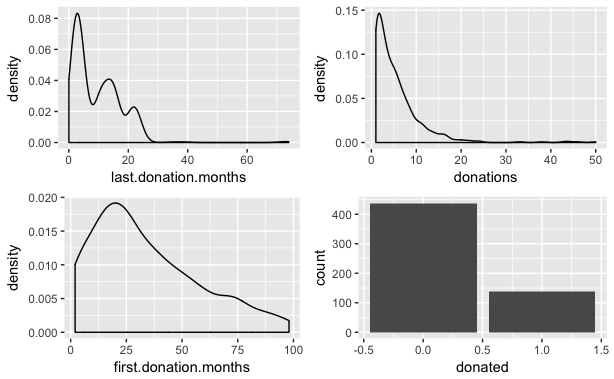

The dataset provided by the competition doesn’t seem to have any outliers or other red flags. The response variable (donated yes/no) is quite skewed towards no donations. This imbalance in the response variable is something we may need to work on down the line.

## Competition Setup

The Drivendata.org Predicting Blood Donations competition gives the you a training dataset and test dataset. In order to rank your submission, you must use the test dataset to generate predictions in a CSV and upload it to their website. The competition metric is [log-loss](https://lingpipe-blog.com/2010/11/02/evaluating-with-probabilistic-truth-log-loss-vs-0-1-loss/), which steeply increases when predictions are confident (i.e. far from 0.5 and closer to 1 or 0) and the wrong classification. The lower the log-loss, the better your rank.

## Logistic Regression

This logistic regression with no variable transformations or other adjustments represents a baseline model. Any other models will be judged against this one.

```r
model.log.reg <- glm(donated ~.,  family=binomial(link = 'logit'), data = train)
summary(model.log.reg)
```

```
Call:
glm(formula = donated ~ ., family = binomial(link = "logit"),
    data = train)

Deviance Residuals:
    Min       1Q   Median       3Q      Max
-2.5102  -0.8079  -0.5273  -0.2427   2.5545

Coefficients:
                       Estimate Std. Error z value Pr(>|z|)
(Intercept)           -0.585643   0.201818  -2.902  0.00371 **
last.donation.months  -0.091026   0.018955  -4.802 1.57e-06 ***
donations              0.129921   0.029102   4.464 8.03e-06 ***
first.donation.months -0.018797   0.006588  -2.853  0.00433 **
---
Signif. codes:  0 ‘***’ 0.001 ‘**’ 0.01 ‘*’ 0.05 ‘.’ 0.1 ‘ ’ 1

(Dispersion parameter for binomial family taken to be 1)

    Null deviance: 634.29  on 575  degrees of freedom
Residual deviance: 556.61  on 572  degrees of freedom
AIC: 564.61

Number of Fisher Scoring iterations: 5
```

### Baseline model submission

```r
submission.log.reg <- predict.glm(model.log.reg, newdata = test, type = 'response')
submission.log.reg <- cbind(test$donor.id, round(submission.log.reg, 4)) %>% as.data.frame()
colnames(submission.log.reg) <- c("", "Made Donation in March 2007")
write_csv(submission.log.reg, 'submission/jhamski_log_reg.csv')
```

The baseline model scores 0.4457, which currently ranks 273 out of 2095 submissions - not bad at all!

## Model 2 -

Idea: a very frequent blood donor is likely to give blood again. However, a person cannon donate blood every month. As seen below, if someone donated blood in the last month it is very unlikely they’ll donate again in the response month.

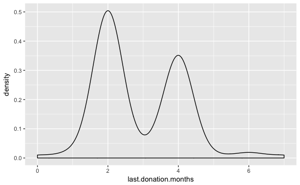

```r
ggplot(train %>% filter(donated == 1) %>% filter(last.donation.months < 8), aes(last.donation.months)) + geom_density()
```

```r
train.2 <- train
train.2$frequency <- train.2$first.donation.months / train.2$donations
train.2 <- mutate(train.2, donation.allowed = last.donation.months > 1)
train.2 <- train.2 %>% select(donated, frequency, donation.allowed, donations, last.donation.months, first.donation.months)
```

```r
model.2 <- glm(donated ~ last.donation.months + frequency + donations + first.donation.months, family=binomial(link='logit'), data=train.2)
summary(model.2)
```

```
Call:
glm(formula = donated ~ last.donation.months + frequency + donations +
    first.donation.months, family = binomial(link = "logit"),
    data = train.2)

Deviance Residuals:
    Min       1Q   Median       3Q      Max
-2.3573  -0.8104  -0.5198  -0.2285   2.5690

Coefficients:
                       Estimate Std. Error z value Pr(>|z|)
(Intercept)           -0.477125   0.245336  -1.945  0.05180 .
last.donation.months  -0.083652   0.021241  -3.938 8.21e-05 ***
frequency             -0.027896   0.036621  -0.762  0.44620
donations              0.109639   0.038185   2.871  0.00409 **
first.donation.months -0.014319   0.008695  -1.647  0.09960 .
---
Signif. codes:  0 ‘***’ 0.001 ‘**’ 0.01 ‘*’ 0.05 ‘.’ 0.1 ‘ ’ 1

(Dispersion parameter for binomial family taken to be 1)

    Null deviance: 634.29  on 575  degrees of freedom
Residual deviance: 556.01  on 571  degrees of freedom
AIC: 566.01

Number of Fisher Scoring iterations: 5
```

```r
test.2 <- test
test.2$frequency <- test.2$first.donation.months / test.2$donations
test.2 <- mutate(test.2, donation.allowed = last.donation.months > 1)
test.2 <- test.2 %>% select(donor.id, frequency, donation.allowed, donations, last.donation.months, first.donation.months)
```

## Conditional Tree

A conditional tree was used via the package [partykit[PDF]](https://cran.r-project.org/web/packages/partykit/vignettes/ctree.pdf).

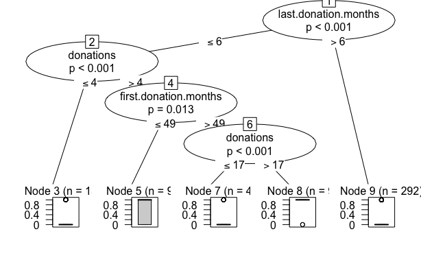

```r
model.3 <- ctree(donated ~ donations + last.donation.months + first.donation.months, data = train)
plot(model.3)
```

This scored score = 1.5393, substantially worse than the logistic regression methods.  
It appears like the baseline logistic regression model performs the best from what I’ve tried so far. But since it’s ranked 273, there’s got to be a way to improve upon it.